# input_quality_manuscript

Erin Campbell & Lillianna Writer

7/20/2022

# Introduction

Language input quality is perhaps even more important [@rowe2012; @hirsh-pasek2015], though somewhat trickier to operationalize. Rowe and Snow [@rowe2020] divide this space into three dimensions of language input quality: interactive features (e.g., parent responsiveness, speech directed *to* child vs. overheard; conversational turn-taking), linguistic features (e.g., lexical diversity, grammatical complexity), and conceptual features (e.g., topic diversity). These features interact with the child’s present cogntive, linguistic, and conceptual abilities.

Interactiveness in parent-child communication is an important element: back-and-forth communicative exchanges predict better language learning across infancy [@goldstein2008; @donnellan2020] and toddlerhood [@hirsh-pasek2015; @romeo2018]. Another aspect of interactiveness is attuning to children’s cues of attention and interest, like pointing or eye gaze. In infancy, words heard in these contexts are more likely to be learned [@lucca2017; @tomasello1986]. This interacts heavily with conceptual features of the language input. Conceptual supportive features of language input involve the relationship between conversational topics and the child’s cognitive level. For example, infants are more likely to learn words when the object is perceptually salient, dominating their field of view [@yu2012]. By contrast, in toddlerhood, parents’ decontextualized language use (e.g., past/future events) predicts kindergarten vocabulary [@rowe2012], children’s decontextualized language use [@demir2015], and academic achievement in adolescence [@uccelli2019].

In terms of linguistic quality, two common ways to quantify it are lexical diversity (often type/token ratio) and syntactic complexity. Lexical diversity of language input seems to exert different effects as children get older. In early infancy, children who are exposed to more repetitions at 7 months have higher vocabulary at age 2 [@newman2016]. This relationship later flips: toddlers who are exposed to greater diversity of words in their language input tend to have larger vocabulary scores [@rowe2012; @anderson2021; @huttenlocher2010; @hsu2017; @weizman2001]. Lexical diversity is intertwined with input quantity: parents who talk more also tend to provide more lexical diversity [@hoff2002]. Likewise, the diversity of syntactic constructions in parental language input is associated both with children’s vocabulary growth and utterance structure diversity [@hoff2003; @naigles1998; @devilliers1984; @huttenlocher2010; @hadley2017; @huttenlocher2002].

For blind children, language input may play an even more important role [@campbell2022]. In the absence of visual input, language is an important source of information about the world. Linguistic structure provides cues to word meaning that may be lost without visual cues (e.g., such as joint (visual) attention or pointing). All that said, language input may differ for blind children relative to sighted children

Speakers regularly tailor input to communicate efficiently with the listener [@grice1975]. Parents are sensitive to their child’s developmental level and tune language input accordingly [@snow1972; @vygotsky1978]. Child-directed speech is one example–whereby parents speak to young children with exaggerated prosody, slower speech rate, and increased vowel clarity [@fernald1989; @bernsteinratner1984], which appears to be helpful to the young language learner [@thiessen2005]. Parents show increased alignment (a tendency to re-use use the conversation partner’s expressions) for younger children, that decreases as children get older [@yurovsky2016]. When interacting with infants and toddlers, parents repeat words more often than when interacting with older children or adults [@snow1972]. Communicative tailoring is also common in language input to children with disabilities, who tend to receive simplified, more directive language input, and less interactive input compared to typically-developing children [@dirks2019; @yoshinaga-itano2020].

In addition to tailoring communication to children’s developmental level, speakers also adjust their conversation in accordance with the listener’s and visual access [@gergle2004; @grigoroglou2016]. Speakers aim to provide the information their listeners lack but avoiding redundant visual description [@ostarek2019; @grice1975]. During in-lab tasks with sighted participants, participants tailor their descriptions and requests by verbally providing visually-absent cues when an object is occluded to their partner [@jaraettinger2021; @hawkins2021; @rubio-fernandez2019]. These results suggest that adults and even infants [@senju2013; @ganea2018; @chiesa2015] can flexibly adapt communication to the visual abilities of their partner.

Curiously though, these results aren’t borne out in the existing literature on interactions between blind infants and their sighted parents. We might expect parents to verbally compensate for missing visual input, resulting in parents providing more description of the child’s environment. Instead, caregivers of blind seem to restrict conversation to things that the blind child is currently engaged with, rather than attempt to redirect their attention to other stimuli [@anderson1993; @campbell2003; @kekelis1984]. In naturalistic settings, parents of blind children use *fewer* declaratives and *more* imperatives and requests for actions/labels than parents of sighted children, suggesting that children might be receiving less description than sighted children [@kekelis1984; @landau1985]. That said, we do see some evidence for parents adapting to their child’s visual abilities. @tadic2013 and colleagues find that in a more structured book reading task, parents of blind children provide more descriptive utterances than parents of sighted children. Further, parents of blind children provide more tactile cues to initiate interactions or establish joint attention [@urwin1983; @preisler1991]. These mixed results suggest that parents of blind children might alter language input in some domains but not others.

Better understanding language how perceptual and linguistic input interact and influence children’s language outcomes is of clinical and scientific relevance. Based on researchers’ interactions with participants’ families in the present study, parents are looking for evidence-based guidance to help them support their children’s language development. If properties of language input influence the likelihood of language delays among blind infants/toddlers [@campbell_inprep], then communicating this to families could help children reach their full potential. By contrast, if there is no relationship between language input properties and children’s language outcomes, then perhaps language input is one fewer worry for caregivers. In the present study, we examine daylong recordings of naturalistic at-home language interactions between caregivers and their blind or sighted children. In order to understand whether parents speak differently to blind children than to sighted children, we first measure input along the dimensions of quantity (adult word count) and quality, split into interactiveness (conversational turn counts, proportion of child-directed vs. adult-directed speech), conceptual features (topic diversity, tense, adjective typicality, sensory modality), and linguistic features (type/token ratio, mean length of utterance). We then link these features of language input to language outcomes, exploring whether the effects of parent language input on child language vary as a function of children’s perceptual ability.

# Methods

## Annotation

Trained annotators listened through each 2-minute segment plus its surrounding context and coded it using the Analyzing Child Language Experiences around the World (ACLEW) Daylong Audio Recording of Children’s Linguistic Environments (DARCLE) annotation scheme [@soderstrom2021]. Prior to annotating lab data, annotators are trained on previously coded samples of child recordings and are required to reach 95% overall agreement with the gold standard version of the file for three different age ranges: 0-7 months, 8-18 months, and 19-36 months. For more information about this annotation scheme and the larger project, please see the ACLEW homepage (https://sites.google.com/view/aclewdid/home). Following the first pass, all files were checked by a highly-trained “superchecker” (second author on this paper, Lilli “Always Right” Righter) to ensure the consistency of annotations. (are we gonna do reliability? I don’t want to lol)

This annotation scheme is designed to capture both utterances by the target child (henceforth referred to as CHI) and speech in the child’s environment, including adults, other children, and pre-recorded electronic speech (e.g. toys, television, the radio). Annotators segment the duration of each utterance on a separate coding tier for each unique speaker (exceptions: all electronic speech is coded on the same tier, and some speakers who appear briefly in these files were not easily distinguishable from others by annotators naive to their identities, so they may be concatenated on the same tier). Speech by people other than the target child is transcribed using an adapted version of CHAT transcription style [@macwhinney2019], dubbed minCHAT for the ACLEW project [@soderstrom2021]. Because the majority of target children in the project are pre-lexical or phonetically immature, CHI utterances are not transcribed.

Each utterance is coded for additional linguistic properties from a set of pre-determined categories. CHI utterances are coded for vocal maturity, lexical status, and multi-word status. Vocal maturity classifies utterances into the following categories: laughing; crying; canonical syllables that contain a consonant-like and vowel-like sound component, including both babbling and identifiable words; non-canonical syllables, which do not contain both consonant and vowel portions, or which do not transition between them in a speech-like way; and unsure, when the vocalization type is unclear. Each vocalization that contains canonical syllables is then coded for lexical status, either containing an identifiable lexical item or not. Finally, each utterance with a lexical item is coded for multi-word status, whether or not it contains more than one unique word type.

Environmental speech is coded for the addressee of each utterance: speech directed to a child, whether or not it is directed to the target child; adult-directed speech; speech directed to both an adult and a child; speech directed to pets or other animals; unclear addressee; or speech directed towards a recipient that doesn’t fit into another category (e.g. voice control of Siri or Alexa, speech to a metaphysical entity).

Following ACLEW DARCLE style annotation [@soderstrom2021], each file was converted into a CHAT file [@macwhinney2018] to use the CLAN automated mean length of utterance (MLU) analysis for each speaker. This analysis finds the average number of morphemes per utterance, using the eng MOR grammar dictionary [@macwhinney2018].

# Results

## Measuring Properties of Language Input

### Language Input Quantity

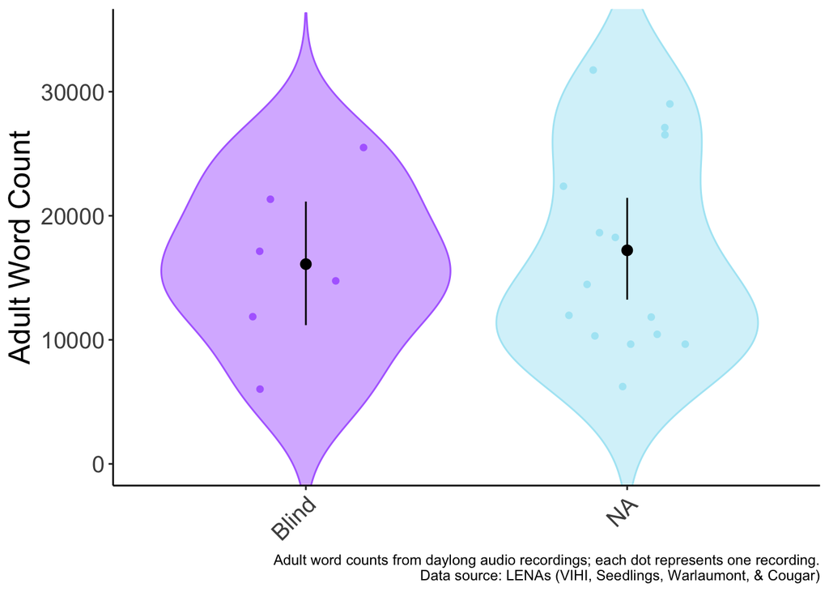

### Language Input Quality

#### Interactiveness

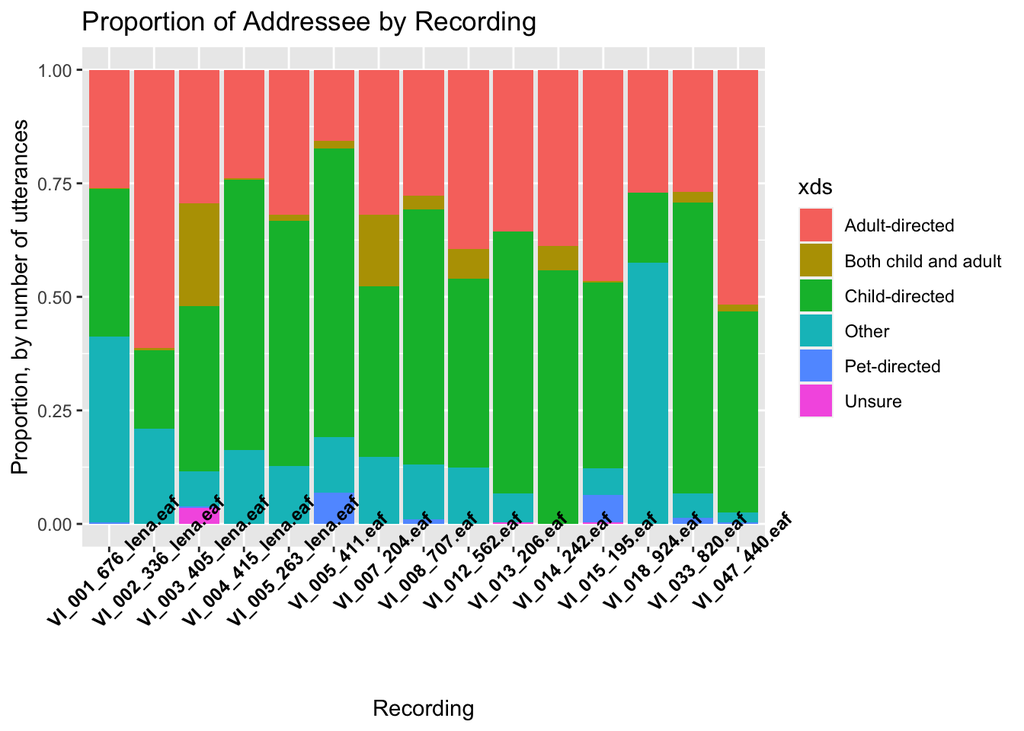

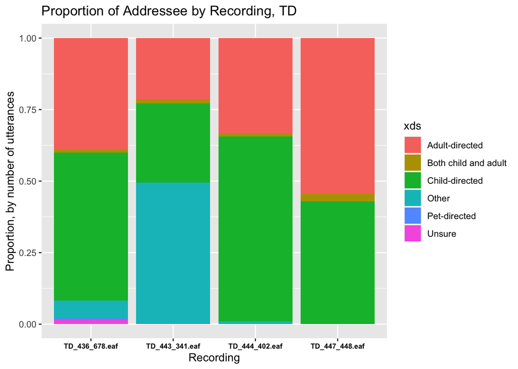

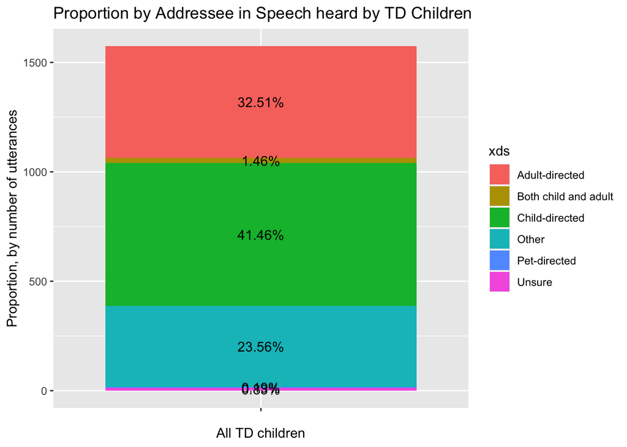

```
##
##  2-sample test for equality of proportions with continuity correction
##
## data:  c(TD_CDS, VI_CDS) out of c(TD_mega_total, mega_total)
## X-squared = 7.49, df = 1, p-value = 0.006204
## alternative hypothesis: two.sided
## 95 percent confidence interval:
##  -0.06898762 -0.01146060
## sample estimates:
##    prop 1    prop 2
## 0.4146032 0.4548273
```

```
##
##  2-sample test for equality of proportions with continuity correction
##
## data:  c(TD_ADS, VI_ADS) out of c(TD_mega_total, mega_total)
## X-squared = 0.41327, df = 1, p-value = 0.5203
## alternative hypothesis: two.sided
## 95 percent confidence interval:
##  -0.03663111  0.01805645
## sample estimates:
##    prop 1    prop 2
## 0.3250794 0.3343667
```

```
##
##  2-sample test for equality of proportions with continuity correction
##
## data:  c(TD_ODS, VI_ODS) out of c(TD_mega_total, mega_total)
## X-squared = 49.494, df = 1, p-value = 1.99e-12
## alternative hypothesis: two.sided
## 95 percent confidence interval:
##  0.05508856 0.10291361
## sample estimates:
##    prop 1    prop 2
## 0.2355556 0.1565545
```

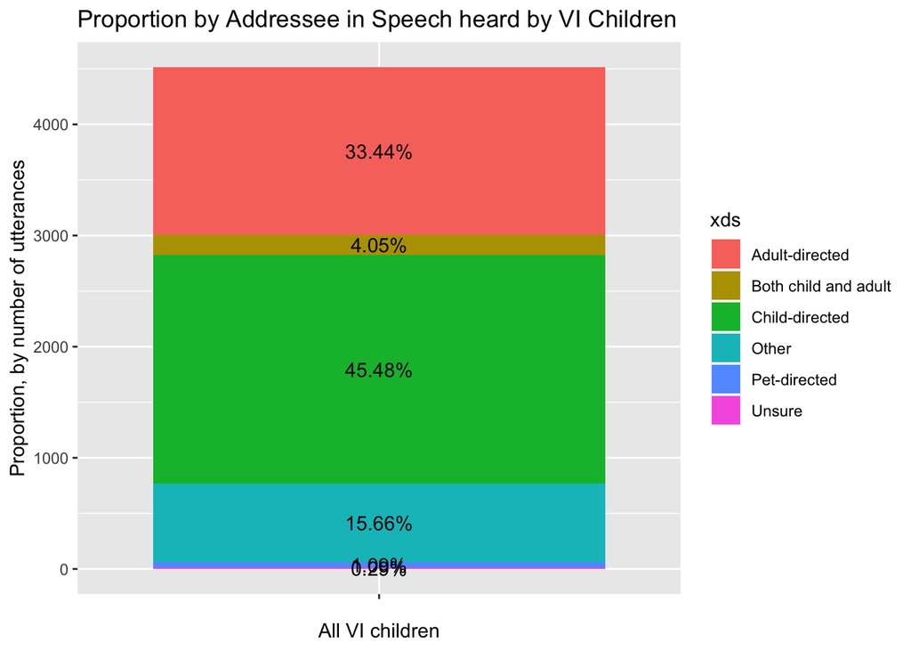

# Discussion

Sighted parents may be unfamiliar with blind children’s signals of interest and engagement [@perezpereira1999], and as a result, may respond less often to infants’ vocalizations and bids for communication [@rowland1984]. Might be hard to provide useful input due to differences in nonverbal communication between blind infants and their sighted caregivers. Young children born with visual impairment may differ in their nonverbal communication cues. For example, [@preisler1995] found that 6–9-month-old blind infants communicated using leaning, eyebrow raising, and lip movements. Caregivers who responded to these nonverbal cues as conversational turns had higher rates of interaction with the child, higher rates of appropriate response, and increased positive affect. By contrast, caregivers who did not recognize these signals as communicative had lower rates of response and increased negative affect.

### random notes

decontextualized speech (not about the here and now) -less decontextualized speech to blind kids -how do we code this in VIHI? less attention shifting? less social engagement? or less flexing of muscle where we learn things through linguistic information alone